# Vignette for traffic safety review

Miao Cai[^1]

Amir Mehdizadeh[^2]

Fadel M. Megahed[^3]

2019-01-25

# 1 Extracting transportation safety data from online sources

## 1.1 Crash-related data

### 1.1.1 Historical data (yearly)

- Federal Motor Carrier Safety Administration (FMCSA)|all truck crashes
- National Highway Traffic Safety Administration (NHTSA)|all fatal crashes

The Motor Carrier Crash Information can be downloaded on Federal Motor Carrier Safety Administration ([FMCSA](https://ai.fmcsa.dot.gov/SMS/Tools/Downloads.aspx)). We download The FMCSA Motor Carrier Crash data on January 15, 2019 and they were collected between December 2016 and December 2018.

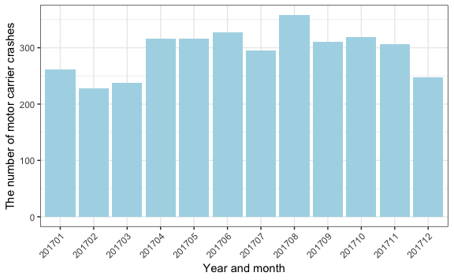

```r
pacman::p_load(data.table, tidyverse, purrr, foreign, knitr, kableExtra, darksky)

fmcsa = data.table::fread("data/Crash_2018Dec/2018Dec_crash.txt")

fmcsa[, REPORT_DATE := lubridate::dmy(REPORT_DATE)]
fmcsa[, ymonth:= paste0(substr(REPORT_DATE, 1, 4), substr(REPORT_DATE, 6, 7))]
fmcsamo = fmcsa[REPORT_STATE == "MO"& year(REPORT_DATE) == 2017]

fmcsamo %>%
  ggplot(aes(x = ymonth)) + geom_bar(fill = "lightblue") +
  xlab("Year and month") + ylab("The number of motor carrier crashes") +
  theme_bw() + theme(axis.text.x = element_text(angle = 45, hjust = 1))
```

```r
knitr::kable(fmcsamo[1:5,], format = "html",
             caption = "All truck crashes in Missouri, 2017") %>%
  kable_styling(bootstrap_options = c("condensed")) %>%
  scroll_box(width = "100%", height = "300px")
```

All truck crashes in Missouri, 2017

| REPORT_NUMBER | REPORT_SEQ_NO | DOT_NUMBER | REPORT_DATE | REPORT_STATE | FATALITIES | INJURIES | TOW_AWAY | HAZMAT_RELEASED | TRAFFICWAY_DESC | ACCESS_CONTROL_DESC | ROAD_SURFACE_CONDITION_DESC | WEATHER_CONDITION_DESC | LIGHT_CONDITION_DESC | VEHICLE_ID_NUMBER | VEHICLE_LICENSE_NUMBER | VEHICLE_LICENSE_STATE | SEVERITY_WEIGHT | TIME_WEIGHT | CITATION_ISSUED_DESC | SEQ_NUM | ymonth |
| --- | --- | --- | --- | --- | --- | --- | --- | --- | --- | --- | --- | --- | --- | --- | --- | --- | --- | --- | --- | --- | --- |
| MO0000065894 | 2 | 73705 | 2017-01-05 | MO | 0 | 0 | Y | N | Two-Way Trafficway Divided Positive Barrier |  | Snow | Snow | Daylight | 3AKJGLDV3ESFW0463 | C11888 | NB | 1 | 1 | UNKNOWN | 1 | 201701 |
| MO0000065895 | 2 | 2823976 | 2017-01-03 | MO | 0 | 0 | Y | N | Two-Way Trafficway Not Divided |  | Dry | No Adverse Conditions | Daylight | JL6BBH1S67K001158 | 41A6BY | MO | 1 | 1 | UNKNOWN | 1 | 201701 |
| MO0000065934 | 2 | 352110 | 2017-01-05 | MO | 0 | 0 | Y | N | Two-Way Trafficway Divided Positive Barrier |  | Ice | Snow | Daylight | 2FZNAJBB1YAF91484 | 84AH6F | MO | 1 | 1 | UNKNOWN | 1 | 201701 |
| MO0000065994 | 1 | 2085921 | 2017-01-04 | MO | 0 | 0 | Y | N | Two-Way Trafficway Divided Unprotected Median |  | Snow | Snow | Dark - Lighted | 3AKJGLD59FSGR6887 | P912031 | IL | 1 | 1 | UNKNOWN | 1 | 201701 |
| MO0000065994 | 2 | 65769 | 2017-01-04 | MO | 0 | 0 | Y | N | Two-Way Trafficway Divided Unprotected Median |  | Snow | Snow | Dark - Lighted | 3HSDJAPR2GN181197 | 189255 | NB | 1 | 1 | UNKNOWN | 1 | 201701 |

All fatal crashes from 1975 to 2017 can be downloaded at National Highway Traffic Safety Administration (NHTSA) official site

```r
require(data.table)

csvpath = './data/FARS2017NationalCSV/'
csvname = list.files(path = csvpath, pattern = "*.csv")
csvpathname = paste0(csvpath, csvname)

nhtsa = purrr::map(csvpathname, fread) %>%
  set_names(gsub(".csv", "", csvname))

csvname
```

```
##  [1] "acc_aux.csv"   "accident.csv"  "cevent.csv"    "Damage.csv"
##  [5] "Distract.csv"  "DrImpair.csv"  "Factor.csv"    "Maneuver.csv"
##  [9] "miacc.csv"     "midrvacc.csv"  "miper.csv"     "nmcrash.csv"
## [13] "NMImpair.csv"  "NMPrior.csv"   "parkwork.csv"  "PBType.csv"
## [17] "per_aux.csv"   "person.csv"    "SafetyEq.csv"  "veh_aux.csv"
## [21] "vehicle.csv"   "VEvent.csv"    "VINDecode.csv" "Violatn.csv"
## [25] "Vision.csv"    "VSOE.csv"
```

### 1.1.2 Real-time data (<= 1 hour)

By state. For example [511pa](https://www.511pa.com/)

## 1.2 Traffic flow data

### 1.2.1 Historical data (yearly)

[FHWA|to obtain AADT](https://www.fhwa.dot.gov/policyinformation/hpms/shapefiles.cfm)

```r
# Using Missouri as an example
fhwai = foreign::read.dbf("data/missouri2017/Missouri2017.dbf")

knitr::kable(fmcsamo[1:5,], format = "html",
             caption = "Historical traffic data in Missouri, 2017") %>%
  kable_styling(bootstrap_options = c("condensed")) %>%
  scroll_box(width = "100%", height = "300px")
```

| REPORT_NUMBER | REPORT_SEQ_NO | DOT_NUMBER | REPORT_DATE | REPORT_STATE | FATALITIES | INJURIES | TOW_AWAY | HAZMAT_RELEASED | TRAFFICWAY_DESC | ACCESS_CONTROL_DESC | ROAD_SURFACE_CONDITION_DESC | WEATHER_CONDITION_DESC | LIGHT_CONDITION_DESC | VEHICLE_ID_NUMBER | VEHICLE_LICENSE_NUMBER | VEHICLE_LICENSE_STATE | SEVERITY_WEIGHT | TIME_WEIGHT | CITATION_ISSUED_DESC | SEQ_NUM | ymonth |
| --- | --- | --- | --- | --- | --- | --- | --- | --- | --- | --- | --- | --- | --- | --- | --- | --- | --- | --- | --- | --- | --- |
| MO0000065894 | 2 | 73705 | 2017-01-05 | MO | 0 | 0 | Y | N | Two-Way Trafficway Divided Positive Barrier |  | Snow | Snow | Daylight | 3AKJGLDV3ESFW0463 | C11888 | NB | 1 | 1 | UNKNOWN | 1 | 201701 |
| MO0000065895 | 2 | 2823976 | 2017-01-03 | MO | 0 | 0 | Y | N | Two-Way Trafficway Not Divided |  | Dry | No Adverse Conditions | Daylight | JL6BBH1S67K001158 | 41A6BY | MO | 1 | 1 | UNKNOWN | 1 | 201701 |
| MO0000065934 | 2 | 352110 | 2017-01-05 | MO | 0 | 0 | Y | N | Two-Way Trafficway Divided Positive Barrier |  | Ice | Snow | Daylight | 2FZNAJBB1YAF91484 | 84AH6F | MO | 1 | 1 | UNKNOWN | 1 | 201701 |
| MO0000065994 | 1 | 2085921 | 2017-01-04 | MO | 0 | 0 | Y | N | Two-Way Trafficway Divided Unprotected Median |  | Snow | Snow | Dark - Lighted | 3AKJGLD59FSGR6887 | P912031 | IL | 1 | 1 | UNKNOWN | 1 | 201701 |
| MO0000065994 | 2 | 65769 | 2017-01-04 | MO | 0 | 0 | Y | N | Two-Way Trafficway Divided Unprotected Median |  | Snow | Snow | Dark - Lighted | 3HSDJAPR2GN181197 | 189255 | NB | 1 | 1 | UNKNOWN | 1 | 201701 |

```r
list.files('data/missouri2017/', pattern='\\.shp$')

# read spatial polygons
sh1 = rgdal::readOGR("data/missouri2017")#YES
sh2 = raster::shapefile("data/missouri2017/Missouri2017.shp") #YES


# read spatial dataframes
df1 = foreign::read.dbf("./data/missouri2017/Missouri2017.dbf")
df2 = sf::read_sf(dsn = "./data/missouri2017/Missouri2017.shp")
df3 = sf::st_read("./data/missouri2017/Missouri2017.shp")
```

### 1.2.2 Real-time data (<= 5 minutes)

- State DoTs|loop detector
- State DoTs|video frames
- [HERE|Phone based](https://developer.here.com/documentation/traffic/topics_v6.1/flow.html)

## 1.3 Weather data

### 1.3.1 Historical (daily)

[NOAA](https://www.ncdc.noaa.gov/)

### 1.3.2 Real-time (<= 1 hour)

In this part, we show how to get both historical and real-time weather data using [DarkSky API](https://darksky.net/dev/docs/libraries). It can be used in both [Python](https://github.com/bitpixdigital/forecastiopy3) and [R](https://github.com/hrbrmstr/darksky). Before using the DarkSky API to get weather data, you need to register for a API key on [its official website](https://darksky.net/dev/register). The first 1000 API requests you make each day are free, but each API request over the 1000 daily limit will cost you $0.0001, which means a million extra API requests will cost you 100 USD.

To get weather data from the DarkSky API, you need to provide the following information on trucks:

1. latitude
2. longitude
3. date and time

Then you can pass these three parameters to the `get_forecast_for()` function in [`darksky`](https://github.com/hrbrmstr/darksky) package in R.

```r
source("private/DarkSkyAPIkey.R")
Sys.setenv(DARKSKY_API_KEY = myDarkSkyAPIkey) # you need to use your own "myDarkSkyAPIkey"

dat = structure(list(
  latitude = c(41.3473127, 41.8189037, 32.8258477, 40.6776808, 40.2366043),
  longitude = c(-74.2850908, -73.0835104, -97.0306677, -75.1450753, -76.9367494),
  time = structure(c(1453101738, 1437508088, 1436195038, 1435243088, 1454270680),
  class = c("POSIXct", "POSIXt"), tzone = "UTC")),
  row.names = c(NA, -5L), class = "data.frame"
)

weather_dat <- pmap(
   list(dat$latitude, dat$longitude, dat$time),
   get_forecast_for)
```

## 1.4 DarkSky returned data

For each datum, data returned by the darksky API includes a list of 3 data.frames:

1. hourly weather data. 24 hourly observations for each 15 weather variables in that day.
2. daily weather data. 1 observations for each 34 weather variables in that day.
3. current weather data. 1 observations for each 15 weather variables at the assigned time point.

The variables include: apparent (feels-like) temperature, atmospheric pressure, dew point, humidity, liquid precipitation rate, moon phase, nearest storm distance, nearest storm direction, ozone, precipitation type, snowfall, sun rise/set, temperature, text summaries, uv index, wind gust, wind speed, wind direction

### 1.4.1 hourly weather

```r
kable(weather_dat[[1]]$hourly) %>%
  kable_styling(full_width = F) %>%
  column_spec(1, width = "20em") %>%
  scroll_box(height = "300px") #width = "100%",
```

| time | summary | icon | precipIntensity | precipProbability | temperature | apparentTemperature | dewPoint | humidity | pressure | windSpeed | windGust | windBearing | cloudCover | uvIndex | visibility |
| --- | --- | --- | --- | --- | --- | --- | --- | --- | --- | --- | --- | --- | --- | --- | --- |
| 2016-01-17 23:00:00 | Overcast | cloudy | 0 | 0 | 27.27 | 27.27 | 24.11 | 0.88 | 1004.61 | 0.77 | 2.59 | 219 | 1.00 | 0 | 10.00 |
| 2016-01-18 00:00:00 | Mostly Cloudy | partly-cloudy-night | 0 | 0 | 26.68 | 26.68 | 23.50 | 0.88 | 1003.95 | 0.81 | 2.66 | 249 | 0.79 | 0 | 10.00 |
| 2016-01-18 01:00:00 | Partly Cloudy | partly-cloudy-night | 0 | 0 | 26.19 | 26.19 | 23.01 | 0.88 | 1004.09 | 1.03 | 4.04 | 265 | 0.49 | 0 | 10.00 |
| 2016-01-18 02:00:00 | Mostly Cloudy | partly-cloudy-night | 0 | 0 | 26.35 | 26.35 | 22.84 | 0.86 | 1004.28 | 2.71 | 7.68 | 264 | 0.64 | 0 | 10.00 |
| 2016-01-18 03:00:00 | Mostly Cloudy | partly-cloudy-night | 0 | 0 | 26.77 | 22.65 | 19.54 | 0.74 | 1004.48 | 3.52 | 12.21 | 290 | 0.75 | 0 | 10.00 |
| 2016-01-18 04:00:00 | Overcast | cloudy | 0 | 0 | 24.82 | 17.83 | 15.50 | 0.67 | 1005.71 | 5.84 | 15.04 | 301 | 1.00 | 0 | 4.55 |
| 2016-01-18 05:00:00 | Overcast | cloudy | 0 | 0 | 20.40 | 12.77 | 11.52 | 0.68 | 1007.11 | 5.64 | 17.41 | 326 | 1.00 | 0 | 8.64 |
| 2016-01-18 06:00:00 | Clear | clear-night | 0 | 0 | 19.03 | 13.49 | 8.08 | 0.62 | 1008.00 | 3.72 | 14.77 | 303 | 0.24 | 0 | 10.00 |
| 2016-01-18 07:00:00 | Clear | clear-day | 0 | 0 | 18.63 | 11.50 | 6.19 | 0.58 | 1008.91 | 4.89 | 15.13 | 311 | 0.00 | 0 | 10.00 |
| 2016-01-18 08:00:00 | Clear | clear-day | 0 | 0 | 19.49 | 11.76 | 6.36 | 0.56 | 1009.32 | 5.57 | 17.34 | 300 | 0.20 | 0 | 10.00 |
| 2016-01-18 09:00:00 | Clear | clear-day | 0 | 0 | 21.14 | 14.00 | 6.38 | 0.52 | 1009.47 | 5.30 | 15.53 | 315 | 0.08 | 1 | 10.00 |
| 2016-01-18 10:00:00 | Clear | clear-day | 0 | 0 | 22.78 | 15.32 | 5.86 | 0.48 | 1009.71 | 5.92 | 16.88 | 309 | 0.12 | 2 | 10.00 |
| 2016-01-18 11:00:00 | Partly Cloudy | partly-cloudy-day | 0 | 0 | 24.11 | 17.41 | 5.23 | 0.44 | 1009.12 | 5.39 | 16.75 | 318 | 0.30 | 2 | 10.00 |
| 2016-01-18 12:00:00 | Partly Cloudy | partly-cloudy-day | 0 | 0 | 24.70 | 16.89 | 2.93 | 0.38 | 1008.97 | 6.77 | 20.25 | 308 | 0.44 | 2 | 10.00 |
| 2016-01-18 13:00:00 | Partly Cloudy | partly-cloudy-day | 0 | 0 | 24.14 | 16.78 | 2.67 | 0.39 | 1008.92 | 6.09 | 19.41 | 313 | 0.59 | 1 | 10.00 |
| 2016-01-18 14:00:00 | Mostly Cloudy | partly-cloudy-day | 0 | 0 | 23.15 | 15.64 | 1.59 | 0.38 | 1009.35 | 6.06 | 18.83 | 297 | 0.75 | 1 | 10.00 |
| 2016-01-18 15:00:00 | Partly Cloudy | partly-cloudy-day | 0 | 0 | 22.16 | 14.88 | 2.69 | 0.42 | 1010.17 | 5.61 | 18.33 | 299 | 0.44 | 0 | 10.00 |
| 2016-01-18 16:00:00 | Partly Cloudy | partly-cloudy-night | 0 | 0 | 20.40 | 14.37 | 4.03 | 0.48 | 1010.93 | 4.24 | 16.11 | 280 | 0.41 | 0 | 10.00 |
| 2016-01-18 17:00:00 | Mostly Cloudy | partly-cloudy-night | 0 | 0 | 19.08 | 12.65 | 5.86 | 0.56 | 1011.85 | 4.39 | 15.06 | 295 | 0.61 | 0 | 10.00 |
| 2016-01-18 18:00:00 | Clear | clear-night | 0 | 0 | 18.57 | 11.49 | 4.81 | 0.54 | 1012.38 | 4.84 | 15.47 | 292 | 0.08 | 0 | 10.00 |
| 2016-01-18 19:00:00 | Clear | clear-night | 0 | 0 | 17.78 | 11.27 | 3.39 | 0.53 | 1012.91 | 4.28 | 15.96 | 284 | 0.04 | 0 | 10.00 |
| 2016-01-18 20:00:00 | Clear | clear-night | 0 | 0 | 17.38 | 10.38 | 3.60 | 0.54 | 1012.91 | 4.61 | 14.81 | 281 | 0.10 | 0 | 10.00 |
| 2016-01-18 21:00:00 | Clear | clear-night | 0 | 0 | 16.84 | 11.01 | 3.70 | 0.56 | 1013.27 | 3.70 | 13.80 | 283 | 0.20 | 0 | 10.00 |
| 2016-01-18 22:00:00 | Clear | clear-night | 0 | 0 | 16.47 | 9.29 | 3.82 | 0.57 | 1013.41 | 4.63 | 13.58 | 287 | 0.17 | 0 | 10.00 |

### 1.4.2 daily weather

```r
kable(weather_dat[[1]]$daily) %>%
  kable_styling(bootstrap_options = c("condensed")) %>%
  scroll_box(height = "200px")
```

| time | summary | icon | sunriseTime | sunsetTime | moonPhase | precipIntensity | precipIntensityMax | precipProbability | temperatureHigh | temperatureHighTime | temperatureLow | temperatureLowTime | apparentTemperatureHigh | apparentTemperatureHighTime | apparentTemperatureLow | apparentTemperatureLowTime | dewPoint | humidity | pressure | windSpeed | windGust | windGustTime | windBearing | cloudCover | uvIndex | uvIndexTime | visibility | temperatureMin | temperatureMinTime | … |
| --- | --- | --- | --- | --- | --- | --- | --- | --- | --- | --- | --- | --- | --- | --- | --- | --- | --- | --- | --- | --- | --- | --- | --- | --- | --- | --- | --- | --- | --- | --- |
| 2016-01-17 23:00:00 | Partly cloudy starting in the afternoon, continuing until evening. | partly-cloudy-day | 2016-01-18 06:20:37 | 2016-01-18 15:56:30 | 0.32 | 0 | 0 | 0 | 24.7 | 1453140000 | 14.1 | 1453204800 | 17.41 | 1453136400 | 6.4 | 1453204800 | 9.05 | 0.59 | 1008.91 | 4.26 | 20.25 | 1453140000 | 299 | 0.43 | 2 | 1453132800 | 9.71 | 16.47 | 2016-01-18 22:00:00 | … |

### 1.4.3 currently weather

```r
kable(weather_dat[[1]]$currently) %>%
  kable_styling(bootstrap_options = c("condensed")) %>%
  scroll_box(height = "100px")
```

| time | summary | icon | precipIntensity | precipProbability | temperature | apparentTemperature | dewPoint | humidity | pressure | windSpeed | windGust | windBearing | cloudCover | uvIndex | visibility |
| --- | --- | --- | --- | --- | --- | --- | --- | --- | --- | --- | --- | --- | --- | --- | --- |
| 2016-01-18 01:22:18 | Partly Cloudy | partly-cloudy-night | 0 | 0 | 26.25 | 26.25 | 22.95 | 0.87 | 1004.16 | 1.65 | 5.39 | 265 | 0.54 | 0 | 10 |

# 2 Descriptive analytic tools used for understanding transportation safety data

## 2.1 Clustering

The following codes attempts to replicate the visual clustering approach from

> Van Wijk, Jarke J., and Edward R. Van Selow. 1999. “Cluster and Calendar Based Visualization of Time Series Data.” In Information Visualization, 1999.(Info Vis’ 99) Proceedings. 1999 IEEE Symposium on, 4-9. IEEE.

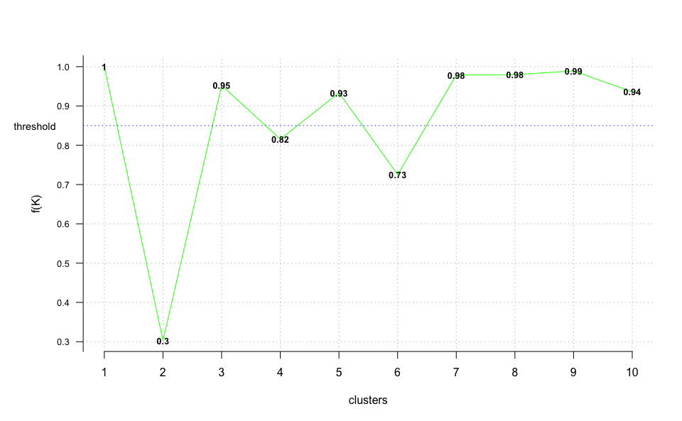

```r
pacman::p_load(data.table,devtools,
       ggplot2,plotly,extrafont,grDevices,RColorBrewer, ggthemes,
       dplyr, stringr,tidyverse,readr,
       rstudioapi,processx,
       ClusterR)

# install_github("jayjacobs/ggcal")
library(ggcal)

trafficflow.df <- read_csv("data/georgia-TFdata-station-121-5505-Yr2015.csv")
trafficflow.df$Date <- as.Date(trafficflow.df$Date, format='%d-%b')

opt = Optimal_Clusters_KMeans(
  as.data.frame(trafficflow.df[,4:27]), max_clusters = 10,
  plot_clusters = T, criterion = 'distortion_fK', fK_threshold = 0.85,
  initializer = 'optimal_init', tol_optimal_init = 0.2,
  max_iters = 10000)
```

```r
num_clusters <- which.min(opt) # Based on the results, we should use k=2 clusters in kmeans
km = KMeans_arma(as.data.frame(trafficflow.df[,4:27]), clusters = num_clusters, n_iter = 10000, seed_mode = "random_subset",
                 verbose = T, CENTROIDS = NULL)
```

```
## kmeans(): generating initial means
## kmeans(): n_threads: 8
## kmeans(): iteration:    1   delta: 8.45358e+06
## kmeans(): iteration:    2   delta: 22935.6
## kmeans(): iteration:    3   delta: 1864.51
## kmeans(): iteration:    4   delta: 0
```

```r
pr = predict_KMeans(data.frame(trafficflow.df[,4:27]), km)
trafficflow.df$cluster.num <- as.vector(pr) %>% as.factor()
table(trafficflow.df$cluster.num)
```

```
##
##   1   2
## 119 246
```

## 2.2 Visualization

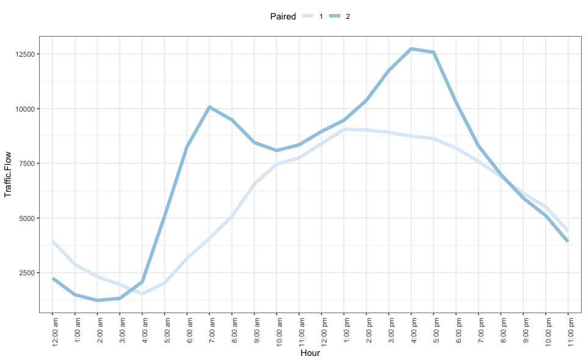

```r
summary.df <- group_by(trafficflow.df,cluster.num)
summary.df <- summarise_all(summary.df,funs(mean))
plot.df <- subset(summary.df, select = -c(2:4))
plot.df <- melt(plot.df, value.name="Traffic.Flow",
                        variable.name="Hour",id.vars="cluster.num")
plot.df$cluster.num <- as.factor(plot.df$cluster.num)

p1 <- ggplot(data = plot.df, aes(x = Hour, y = Traffic.Flow, group=cluster.num,
                           color=cluster.num)) + geom_line(size=2) +
  theme_bw() +
  theme(legend.position="top", axis.text.x=element_text(angle=90, hjust=1)) +
  scale_color_brewer("Paired")
p1
```

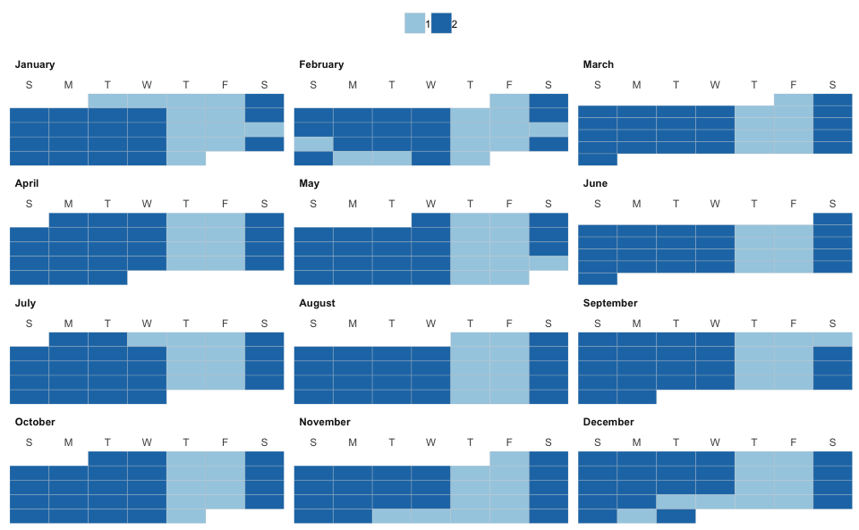

```r
col.brewer.pal <- brewer.pal(11, "Paired")
p2 <- ggcal(trafficflow.df$Date,trafficflow.df$cluster.num) +
  theme(legend.position="top") +
  scale_fill_manual(values = c("1"=col.brewer.pal[1], "2"=col.brewer.pal[2]))
p2
```

[^1]: Department of Epidemiology and Biostatistics, Saint Louis University. Email address miao.cai@slu.edu
[^2]: Department of Industrial and Systems Engineering, Auburn University. Email address azm0127@auburn.edu
[^3]: Farmer School of Business, Miami University. Email address fmegahed@miamioh.edu.